# SQ 024

## Shared Qs (024)

#### Question

1. Consider the right triangle with lengths 20, 21, 29 and acute angles $\phi$ and $\theta$, where $\theta<\phi$. Find all the [trigonometric ratios](https://en.wikipedia.org/wiki/Trigonometric_functions#Right-angled_triangle_definitions).

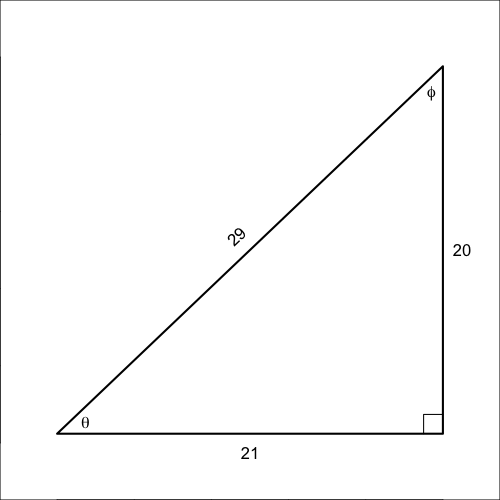

   - $\sin(\theta)$ = /
   - $\cos(\theta)$ = /
   - $\tan(\theta)$ = /
   - $\csc(\theta)$ = /
   - $\sec(\theta)$ = /
   - $\cot(\theta)$ = /
   - $\sin(\phi)$ = /
   - $\cos(\phi)$ = /
   - $\tan(\phi)$ = /
   - $\csc(\phi)$ = /
   - $\sec(\phi)$ = /
   - $\cot(\phi)$ = /

#### Question

2. Consider the right triangle with lengths 5, 12, 13 and acute angles $\phi$ and $\theta$, where $\theta<\phi$. Find all the [trigonometric ratios](https://en.wikipedia.org/wiki/Trigonometric_functions#Right-angled_triangle_definitions).

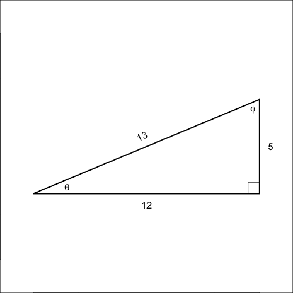

   - $\sin(\theta)$ = /
   - $\cos(\theta)$ = /
   - $\tan(\theta)$ = /
   - $\csc(\theta)$ = /
   - $\sec(\theta)$ = /
   - $\cot(\theta)$ = /
   - $\sin(\phi)$ = /
   - $\cos(\phi)$ = /
   - $\tan(\phi)$ = /
   - $\csc(\phi)$ = /
   - $\sec(\phi)$ = /
   - $\cot(\phi)$ = /

#### Question

3. An adventurer, crossing a vast (flat) desert, approaches a distant monument. When the adventurer first notices the monument, the viewing angle (the [angle of elevation](https://www.khanacademy.org/math/geometry/hs-geo-trig/hs-geo-modeling-with-right-triangles/a/angles-of-elevation-and-depression) to the top of the monument) is 0.55 radians.

   The adventurer walks toward the monument, getting 450 meters closer; the viewing angle increases to 1.3 radians.

   How tall is the monument (in meters)?

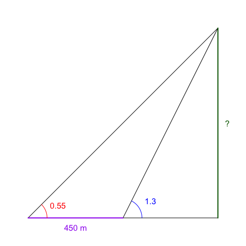

   (Figure not drawn to scale.)

   PLEASE ROUND YOUR ANSWER TO 2 [SIGNIFICANT FIGURES](https://en.wikipedia.org/wiki/Significant_figures).

#### Question

4. An adventurer, crossing a vast (flat) desert, approaches a distant monument. When the adventurer first notices the monument, the viewing angle (the [angle of elevation](https://www.khanacademy.org/math/geometry/hs-geo-trig/hs-geo-modeling-with-right-triangles/a/angles-of-elevation-and-depression) to the top of the monument) is 0.27 radians.

   The adventurer walks toward the monument, getting 460 meters closer; the viewing angle increases to 0.87 radians.

   How tall is the monument (in meters)?

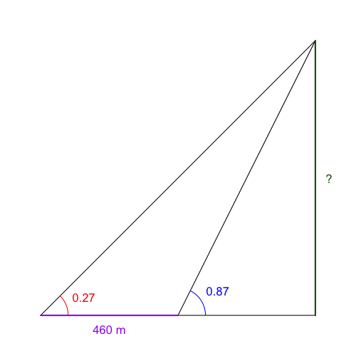

   (Figure not drawn to scale.)

   PLEASE ROUND YOUR ANSWER TO 2 [SIGNIFICANT FIGURES](https://en.wikipedia.org/wiki/Significant_figures).

#### Question

5. Find $x$. The angles are measured in radians.

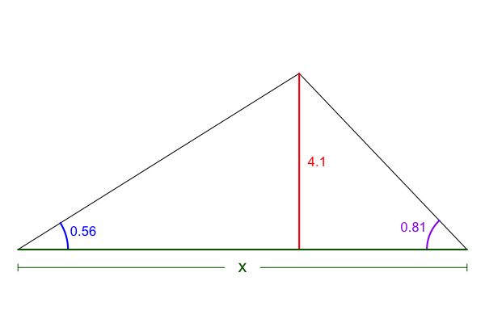

   The tolerance is $\pm 0.01$.

#### Question

6. Find $x$. The angles are measured in radians.

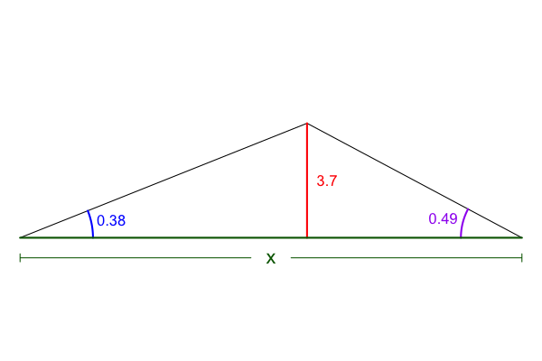

   The tolerance is $\pm 0.01$.

#### Question

7. A ship sailed 5.8 miles in a direction of 31° North of East. The ship turned and sailed 6.7 miles in a direction 52° North of East.

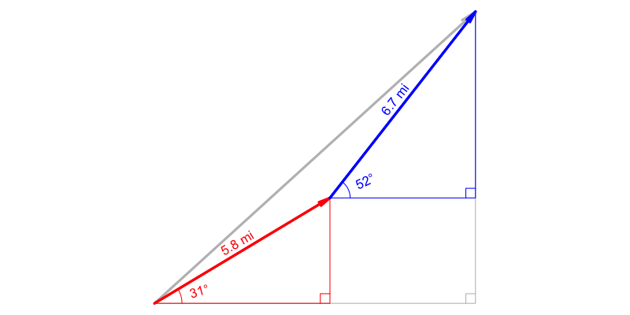

   The ship’s captain suffers a terrible accident. The first officer radios for help and sets anchor, waiting for help while administering first aid.

   A helicopter, starting where the ship started, wishes to fly directly to the ship. What direction ($\theta$ rounded to nearest degree) and distance ($r$ rounded to nearest tenth of a mile) should the helicopter fly?

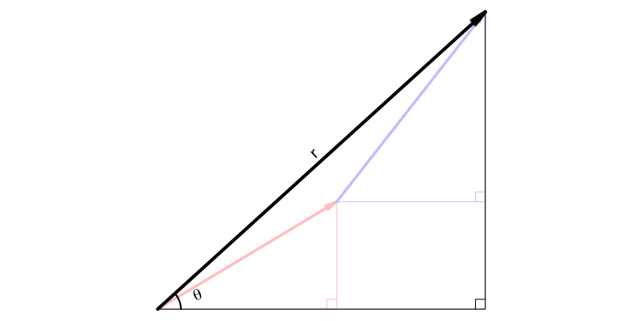

   - The direction: $\theta =$
   - The distance: $r =$

#### Question

8. A ship sailed 6.9 miles in a direction of 18° North of East. The ship turned and sailed 7.9 miles in a direction 42° North of East.

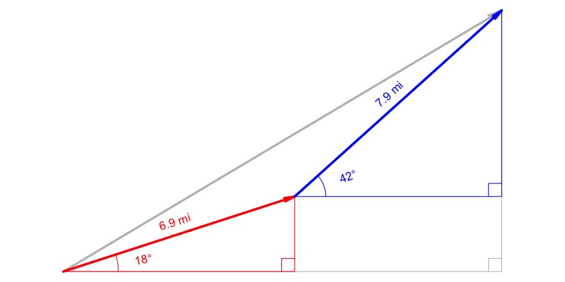

   The ship’s captain suffers a terrible accident. The first officer radios for help and sets anchor, waiting for help while administering first aid.

   A helicopter, starting where the ship started, wishes to fly directly to the ship. What direction ($\theta$ rounded to nearest degree) and distance ($r$ rounded to nearest tenth of a mile) should the helicopter fly?

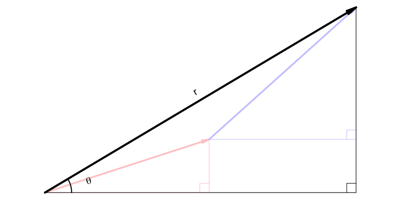

   - The direction: $\theta =$
   - The distance: $r =$

#### Question

9. A line forms an angle of inclination of $\theta=0.79$ radians with the horizontal axis. What is the slope of the line?

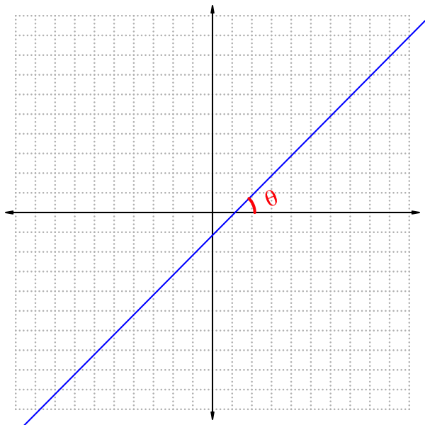

   In other words, the line could be represented with a linear equation, $y=mx+b$, and your goal is to determine $m$.

   The tolerance is $\pm 0.01$.

#### Question

10. A line forms an angle of inclination of $\theta=-0.64$ radians with the horizontal axis. What is the slope of the line?

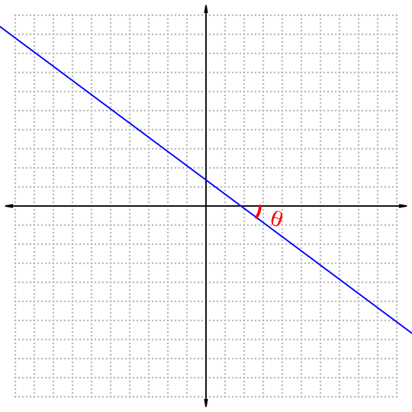

    In other words, the line could be represented with a linear equation, $y=mx+b$, and your goal is to determine $m$.

    The tolerance is $\pm 0.01$.

#### Question

11. On steep streets, you may see signs that indicate the grade, which is usually shown as a percentage. The grade is equivalent to [slope](https://en.wikipedia.org/wiki/Slope), written as a percentage.

    The highest grade of the Ashuwillticook Rail Trail is 2.5%. The Mohawk Trail (Route 2), near the hairpin turn, has sections of 8% grade. Notch Road, heading up Mount Greylock, has grades as high as 12%. Circuit Road, below Berry Pond in Pittsfield State Forest, has a section of 16% grade. Thunderbolt Ski Trail’s steepest section has 35% grade.

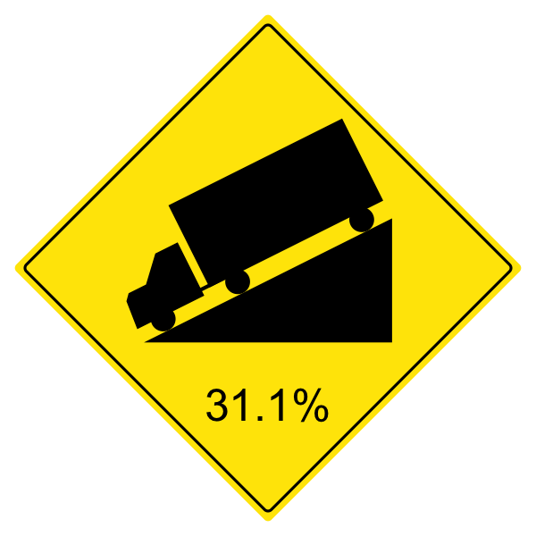

    A grade of 31.1% implies that for every 100 feet of horizontal travel (as seen on a map), the elevation changes by 31.1 feet. We wish to determine the angle of inclination (in degrees) of a 31.1% grade.

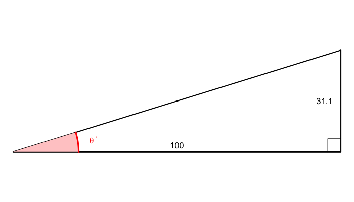

    Find $\theta$, the angle of inclination in degrees. The tolerance is $\pm0.1^\circ$.

#### Question

12. On steep streets, you may see signs that indicate the grade, which is usually shown as a percentage. The grade is equivalent to [slope](https://en.wikipedia.org/wiki/Slope), written as a percentage.

    The highest grade of the Ashuwillticook Rail Trail is 2.5%. The Mohawk Trail (Route 2), near the hairpin turn, has sections of 8% grade. Notch Road, heading up Mount Greylock, has grades as high as 12%. Circuit Road, below Berry Pond in Pittsfield State Forest, has a section of 16% grade. Thunderbolt Ski Trail’s steepest section has 35% grade.

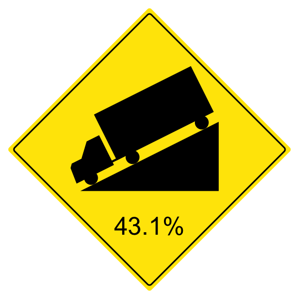

    A grade of 43.1% implies that for every 100 feet of horizontal travel (as seen on a map), the elevation changes by 43.1 feet. We wish to determine the angle of inclination (in degrees) of a 43.1% grade.

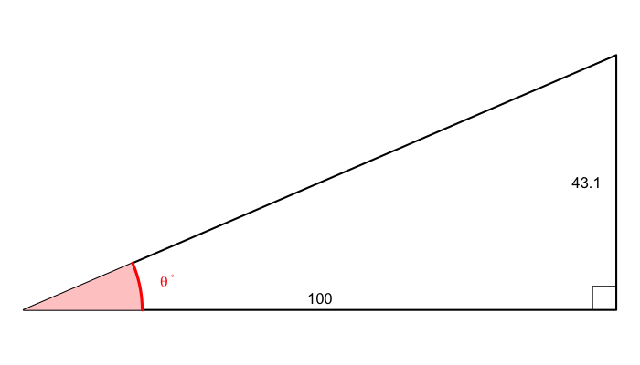

    Find $\theta$, the angle of inclination in degrees. The tolerance is $\pm0.1^\circ$.

#### Question

13. A point on a Cartesian plane is denoted in [polar coordinates](https://en.wikipedia.org/wiki/Polar_coordinate_system):
    $$r = 3.36$$
    $$\theta=\frac{20\pi}{11}$$

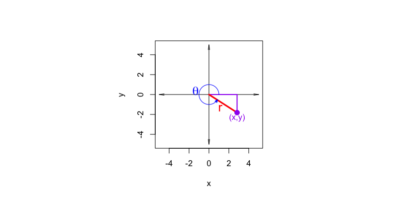

    Please determine the rectangular coordinates ($x$ and $y$).
    - The horizontal coordinate: $x=$
    - The vertical coordinate: $y=$

#### Question

14. A point on a Cartesian plane is denoted in [polar coordinates](https://en.wikipedia.org/wiki/Polar_coordinate_system):
    $$r = 4.72$$
    $$\theta=\frac{20\pi}{11}$$

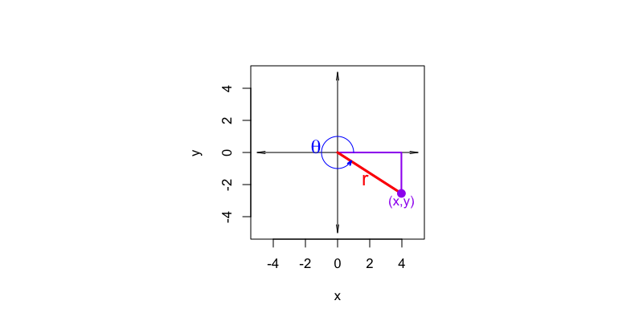

    Please determine the rectangular coordinates ($x$ and $y$).
    - The horizontal coordinate: $x=$
    - The vertical coordinate: $y=$